# Guinea Pigs Tooth Growth Data Analysis

Sam Hewamanage

August 4, 2014

## Problem

Now in the second portion of the class, we’re going to analyze the ToothGrowth data in the R datasets package.

1. Load the ToothGrowth data and perform some basic exploratory data analyses
2. Provide a basic summary of the data.
3. Use confidence intervals and hypothesis tests to compare tooth growth by supp and dose. (Use the techniques from class even if there’s other approaches worth considering)
4. State your conclusions and the assumptions needed for your conclusions.

## Analysis

### Observations:

```r
rm(list=ls())
set.seed(1234)
data(ToothGrowth)
str(ToothGrowth)
```

```
## 'data.frame':    60 obs. of  3 variables:
##  $ len : num  4.2 11.5 7.3 5.8 6.4 10 11.2 11.2 5.2 7 ...
##  $ supp: Factor w/ 2 levels "OJ","VC": 2 2 2 2 2 2 2 2 2 2 ...
##  $ dose: num  0.5 0.5 0.5 0.5 0.5 0.5 0.5 0.5 0.5 0.5 ...
```

```r
summary(ToothGrowth)
```

```
##       len       supp         dose
##  Min.   : 4.2   OJ:30   Min.   :0.50
##  1st Qu.:13.1   VC:30   1st Qu.:0.50
##  Median :19.2           Median :1.00
##  Mean   :18.8           Mean   :1.17
##  3rd Qu.:25.3           3rd Qu.:2.00
##  Max.   :33.9           Max.   :2.00
```

```r
head(ToothGrowth)
```

```
##    len supp dose
## 1  4.2   VC  0.5
## 2 11.5   VC  0.5
## 3  7.3   VC  0.5
## 4  5.8   VC  0.5
## 5  6.4   VC  0.5
## 6 10.0   VC  0.5
```

### Observations:

There is dependence of tooth legth (len) on dose and suppliment type. The width of len distribution gets smaller with the dose (approximately).

| Observation | OJ | VC |
| --- | --- | --- |
| shape | left skewed | more symmetric |
| correlation | strong | weak |
| spread | narrow | much broader |

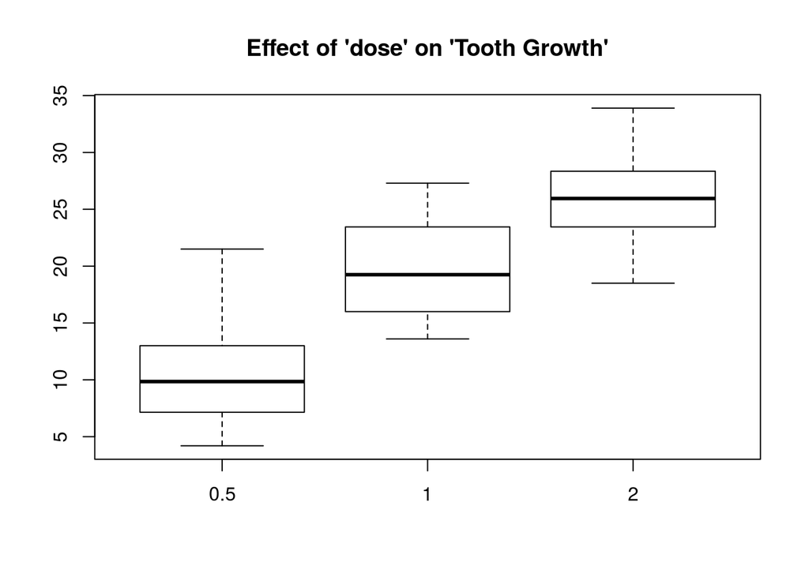

```r
library(ggplot2)
p <- ggplot(data=ToothGrowth)

boxplot(len ~ dose, data=ToothGrowth)
title("Effect of 'dose' on 'Tooth Growth'")
```

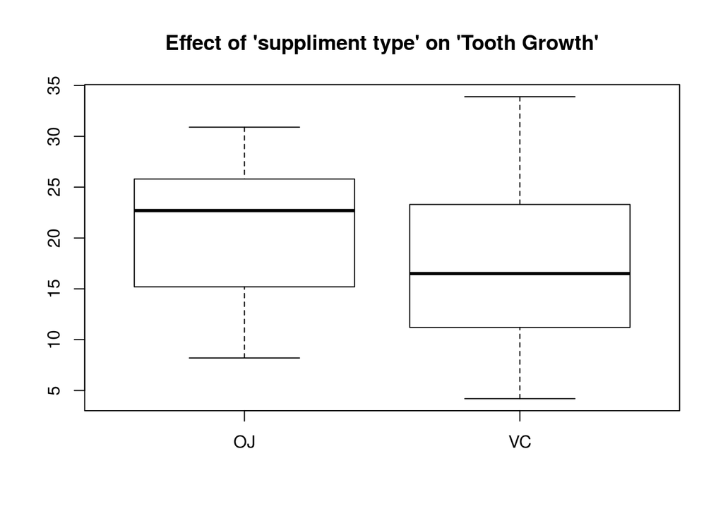

```r
boxplot(len ~ supp, data=ToothGrowth)
title("Effect of 'suppliment type' on 'Tooth Growth'")
```

### Compare the additive model with interaction model and a model with both.

With the factors the additive explains ~70% of the variance. The interaction model itself show ~72% correction which is slightly higher than the additive model.

### Addtive Model (1)

```r
lm.form.1 = formula('len ~ dose + supp')
lm.form.1
```

```
## len ~ dose + supp
```

```r
#oj.df <- subset(ToothGrowth, supp=='OJ')
#lm.model.1 <- lm(lm.form.1, data=oj.df)
lm.model.1 <- lm(lm.form.1, data=ToothGrowth)
summary(lm.model.1)
```

```
##
## Call:
## lm(formula = lm.form.1, data = ToothGrowth)
##
## Residuals:
##    Min     1Q Median     3Q    Max
## -6.600 -3.700  0.373  2.116  8.800
##
## Coefficients:
##             Estimate Std. Error t value Pr(>|t|)
## (Intercept)    9.273      1.282    7.23  1.3e-09 ***
## dose           9.764      0.877   11.14  6.3e-16 ***
## suppVC        -3.700      1.094   -3.38   0.0013 **
## ---
## Signif. codes:  0 '***' 0.001 '**' 0.01 '*' 0.05 '.' 0.1 ' ' 1
##
## Residual standard error: 4.24 on 57 degrees of freedom
## Multiple R-squared:  0.704,  Adjusted R-squared:  0.693
## F-statistic: 67.7 on 2 and 57 DF,  p-value: 8.72e-16
```

```r
confint(lm.model.1)
```

```
##              2.5 % 97.5 %
## (Intercept)  6.705  11.84
## dose         8.008  11.52
## suppVC      -5.890  -1.51
```

### Interaction Model (2)

```r
lm.form.2 = formula('len ~ dose * supp')
lm.form.2
```

```
## len ~ dose * supp
```

```r
lm.model.2 <- lm(lm.form.2, data=ToothGrowth)
summary(lm.model.2)
```

```
##
## Call:
## lm(formula = lm.form.2, data = ToothGrowth)
##
## Residuals:
##    Min     1Q Median     3Q    Max
##  -8.23  -2.85   0.05   2.29   7.94
##
## Coefficients:
##             Estimate Std. Error t value Pr(>|t|)
## (Intercept)    11.55       1.58    7.30  1.1e-09 ***
## dose            7.81       1.20    6.53  2.0e-08 ***
## suppVC         -8.26       2.24   -3.69  0.00051 ***
## dose:suppVC     3.90       1.69    2.31  0.02463 *
## ---
## Signif. codes:  0 '***' 0.001 '**' 0.01 '*' 0.05 '.' 0.1 ' ' 1
##
## Residual standard error: 4.08 on 56 degrees of freedom
## Multiple R-squared:  0.73,   Adjusted R-squared:  0.715
## F-statistic: 50.4 on 3 and 56 DF,  p-value: 6.52e-16
```

```r
confint(lm.model.2)
```

```
##                2.5 % 97.5 %
## (Intercept)   8.3821 14.718
## dose          5.4167 10.206
## suppVC      -12.7351 -3.775
## dose:suppVC   0.5176  7.291
```

Compare the two models

```r
anova(lm.model.1, lm.model.2)
```

```
## Analysis of Variance Table
##
## Model 1: len ~ dose + supp
## Model 2: len ~ dose * supp
##   Res.Df  RSS Df Sum of Sq    F Pr(>F)
## 1     57 1023
## 2     56  934  1      88.9 5.33  0.025 *
## ---
## Signif. codes:  0 '***' 0.001 '**' 0.01 '*' 0.05 '.' 0.1 ' ' 1
```

The interaction term is significant and hence this model does better than previous model in explaining the variance.

### Conclusions

Both dependent variables are significant in describing the dependent variable, len. The interaction model seems to be a slightly better than additive model of the same variables as it seems to decribes the variance a tad more. Both models’ p-values are signficant and hence we reject null hypothesis in favor of the alternate, `the variable are correlated’. Futher more there is indication that the interaction between dependent variables is significant as evident by the higher adjusted R-squared in the interaction model.

In conclusion, there is evidence that that dosage of vitamin C and the intake form have positive effect on the Guinea pigs’ tooth growth.